# Homework 3

Linguistic Data: Quantitative Analysis and Visualisation

Deadline: 9 February, 12:00

The solutions should be submitted via GitHub.

## Part 1. A preliminary training

*Do not use R (RStudio) to solve problems in Part 1. Answers won’t be evaluated.*

### Problem 1

Look at the following histogram and answer the questions.

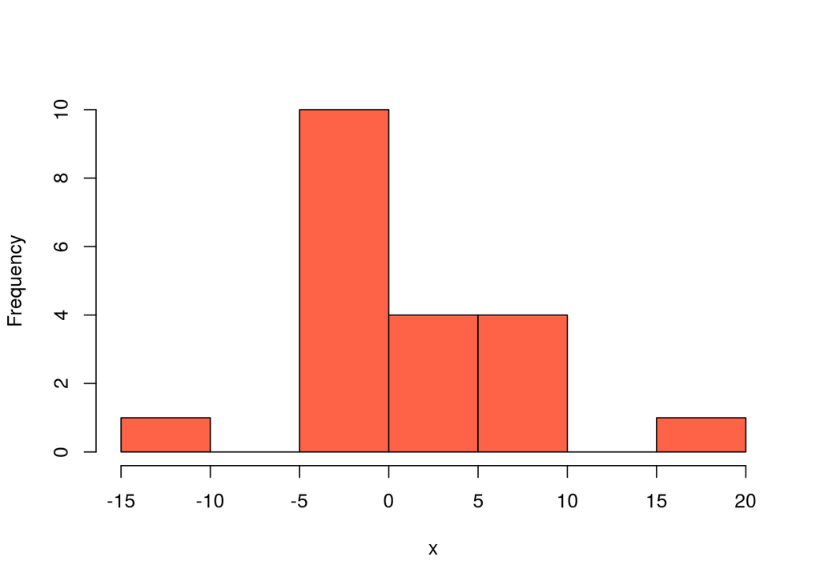

1. What is the proportion of values in the sample that exceed $5$? Explain your answer.

Answer: it’s 1/4, because there seems to be 20 values in total in the sample and 5 of them are plotted on the right of x = 5. 5/20 = 1/4.

2. Indicate the interval where the median of this sample can lie. Explain your answer.

Answer: It may lie in the interval (-5:0), because here the median is calculated as a mean of the tenth and the eleventh values of the ordered sample and they lie in this interval.

3. How the histogram will change if we add an element $7$ to the sample? Explain your answer.

Answer: the frequency of values lying in the (5:10) interval will get higher, so does the corresponding bar.

### Problem 2

1. Look at the histograms of two samples. They illustrate the distribution of normalized average reaction time to frequent words (in ms) in two groups of people.

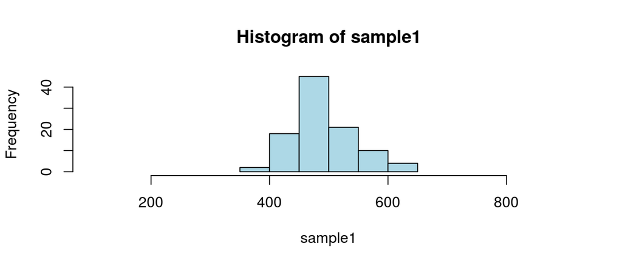

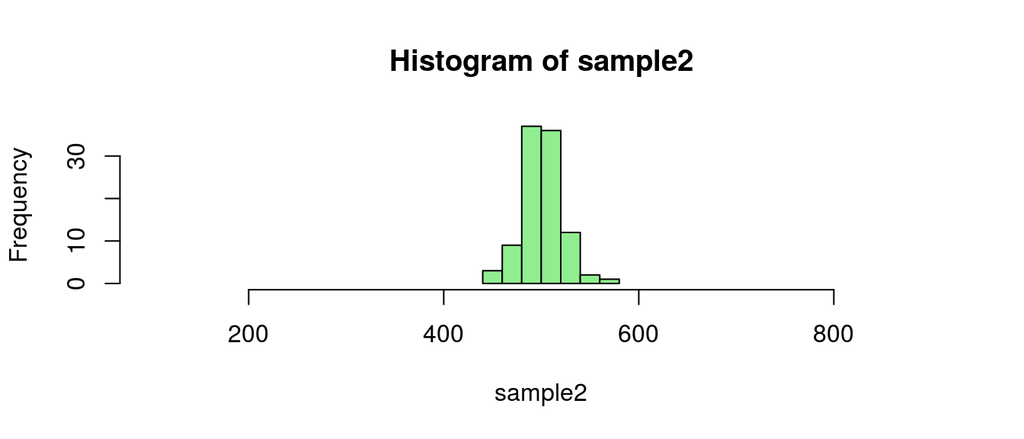

Which of the samples has a larger variance? Explain your answer.

Answer: The first sample has larger variance, because here there are values differ more (from what seems to be a mean of the distribution).

2. Look at the histograms of two samples.

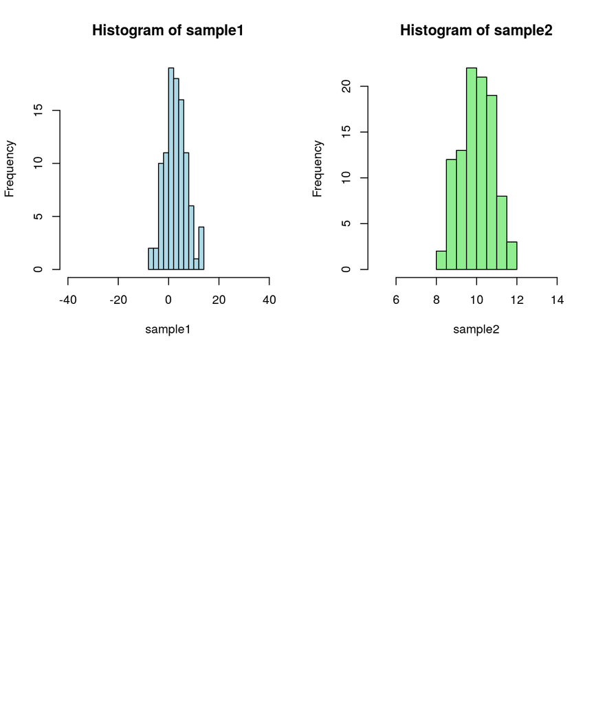

Which of the samples has a larger variance? Explain your answer.

Answer: The first sample may have a larger variance, as here values occupy broader interval, than those of the second sample.

## Part 2

*Do not use R (RStudio) to solve problems in Part 2. Answers for problem 3 will be evaluated. Please paste YES or NO into (empty) code blocks and explain you answer below the block.*

### Problem 3

Below is the histogram of the number of mistakes students made while writing an examination essay in English. Look at the histogram and answer the questions.

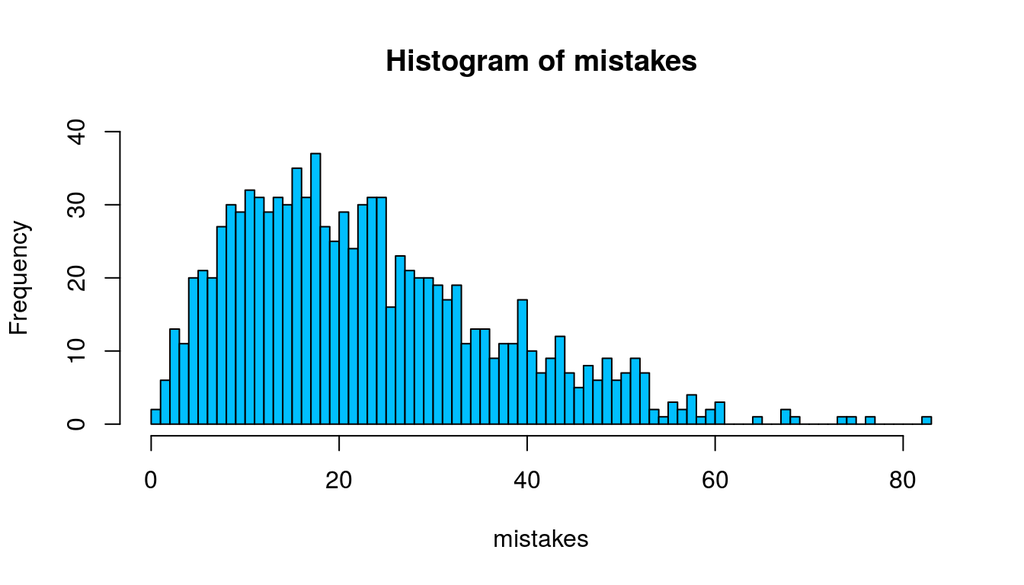

### 3.1

Is it true that $50$% students made more than $35$ mistakes?

```
NO
```

Explain your answer below: The distribution shows that there are more students who made less mistakes than that (than 35).

### 3.2

Is it true that most students made no more than $10$ mistakes?

```
NO
```

Explain your answer below: There seems to be much more values on the right of the 10 value (which is somewhere in the middle between 0 and 20 on the mistakes axis).

### 3.3

Which of the following values is closer to be the median of `mistakes`: $10$, $20$, $30$, $40$?

```
20
```

Explain your answer below: There are seemingly equal number of values distributed on the left and on the right of 20.

### Problem 4. Exact binomial test

The null hypothesis is that $p=0$ (i.e. no success is possible). In a dataset, there is only one success out of 1 000 000 observations. Will you reject the null hypothesis?

```
NO
```

Explain your answer below: The alternative hypothesis is that there might be more than 0 successes. The possibility of one or more successes is very small and p-value here lies on the left of the 0.05 alpha threshold.

## Part 3

*Use R (RStudio) to solve problems in Part 3. Your answers will be evaluated. Please paste R code into R code blocks and explain you answer below the block, if needed.*

### Problem 5

Here is a sample of respondents’ age:

$44$, $50$, $42$, $64$, $66$, $42$, $72$, $56$, $72$, $54$, $46$, $48$, $48$, $52$, $50$, $66$, $84$.

### 5.1

Arrange them in a vector and call it `age`.

```r
age <- c(44, 50, 42, 64, 66, 42, 72, 56, 72, 54, 46, 48, 48, 52, 50, 66, 84)
```

### 5.2

Examine the type of `age` variable (numeric, character, etc).

```r
class(age)
```

```
## [1] "numeric"
```

### 5.3

Plot the histogram of the vector `age` with $5$ bins. Change its color to any you want. (Use either R basic or ggplot2 style for plotting.)

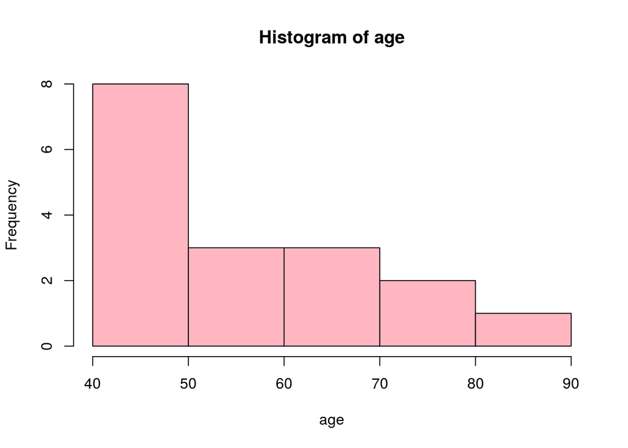

```r
hist(age, col="lightpink", breaks = 5)
```

### Problem 6

Here is a series of words:  
*pie, bar, bar, pie, pie, bar, bar, chart*.

### 6.1

Arrange elements above in a vector and call it `words`

```r
words = c("pie", "bar", "bar", "pie", "pie", "bar", "bar", "chart")
```

### 6.2

Calculate the relative frequences of values in `words` measured in percent.

```r
#Freq(words)
(table(words)/sum(table(words)))*100
```

```
## words
##   bar chart   pie
##  50.0  12.5  37.5
```

## Problem 7. Position of verbs in verses

The dataset [“The last words in verses”](https://raw.githubusercontent.com/LingData2019/LingData2020/master/data/poetry_last_in_lines.csv) is based on texts written in the 1820s and 1920s (Corpus of Russian Poetry of the Russian National Corpus). Authors collected only one line per author to keep observations as independent from each other as possible.

Variables:  
- Decade — decade of creation: 1820s, 1920s.  
- RhymedNwords — the number of words in the rhyming position (usually one word, but there are two words in cases such as *вина бы* ‘I would like to get) wine’ (which is rhymed with *жабы* ‘toad’, see http://russian-poetry.ru/Poem.php?PoemId=18261)).  
- RhymedNsyl — the number of syllables in the rhyming position.  
- UPoS — part of speech of the last word. - LineText — a sampled verse.  
- Author — the author of the text.

Can we decide that in verses written in 1920s, verbs in the rhyming posision are used differently (more often or less often) than expected for verbs in general?

### 7.1 State hypothesis

What is your null hypothesis $H_0$ and what is the alternative hypothesis $H_1$?

```
H0: In verses written in 1920s, verbs in the rhyming posision are used in the same way verbs are used in general (with probability of 0,17).
H1: In verses written in 1920s, verbs in the rhyming posision are used differently (more often or less often) than expected for verbs in general (the probability is not 0,17).
```

### 7.2

Read the dataset [“The last words in verses”](https://raw.githubusercontent.com/LingData2019/LingData2020/master/data/poetry_last_in_lines.csv). Filter out the relevant observations from 1920s, calculate the number of verbs observed in the sample, and the sample size.

```r
df <- read.csv("https://raw.githubusercontent.com/LingData2019/LingData2020/master/data/poetry_last_in_lines.csv", sep = "\t")
```

Observations from 1920s:

```r
twentieth_century <- df[df$Decade=='1920s',]
```

Calculate the number of verbs observed in the sample

```r
nverbs = nrow(twentieth_century[twentieth_century$UPoS=='VERB',])
nverbs
```

```
## [1] 39
```

The sample size:

```r
sample_size = nrow(twentieth_century)
sample_size
```

```
## [1] 277
```

### 7.3

Use an exact binomial test to calculate p-value.

```r
binom.test(nverbs, sample_size, p=0.17)
```

```
##
##  Exact binomial test
##
## data:  nverbs and sample_size
## number of successes = 39, number of trials = 277, p-value = 0.2297
## alternative hypothesis: true probability of success is not equal to 0.17
## 95 percent confidence interval:
##  0.1020719 0.1874081
## sample estimates:
## probability of success
##              0.1407942
```

### 7.4 Interpret results

Give your interpretation of obtained p-value. Answer the initial question: Can we decide that in verses written in 1920s, verbs are used in the rhyming position more often or less often than expected?

```
No, we can't, because the obtained p-value is not small enough. It is much bigger than alpha (0.05). Thus, we can't reject the null hypothesis
```

### 7.5

*(A bonus problem, extra points in evaluation)*. Repeat 2.3 for verses written in the 1820s.

```r
nineteenth_century <- df[df$Decade=='1820s',]
```

```r
nverbs = nrow(nineteenth_century[nineteenth_century$UPoS=='VERB',])
nverbs
```

```
## [1] 15
```

```r
sample_size = nrow(nineteenth_century)
sample_size
```

```
## [1] 87
```

```r
binom.test(nverbs, sample_size, p=0.17)
```

```
##
##  Exact binomial test
##
## data:  nverbs and sample_size
## number of successes = 15, number of trials = 87, p-value = 0.8873
## alternative hypothesis: true probability of success is not equal to 0.17
## 95 percent confidence interval:
##  0.09983452 0.26837791
## sample estimates:
## probability of success
##              0.1724138
```

Write down your general conlusions about data provided for both 1920s and 1820s data.

```
Both data samples show that there's not much difference in the use of verbs comparing to general probability of a verb occuring at the end of the line. Anyway, the null hypothesis can't be rejected and we can't say that verbs are used differently in the rhyming position during these periods of time.
```

### Problem 8. One-sample t-test

Using Icelandic data on vowel duration from seminar [Link](https://raw.githubusercontent.com/LingData2019/LingData2020/master/data/icelandic.csv) test the null hypothesis that the population mean of vowel duration in speaker `shg05` equals 73 (ms). To perform a one-sample t-test, you can use the following example of R code:

```
t.test(sample, mu = 7725) # mu is a population mean
```

### 8.1

Write down a two-tailed alternative hypothesis.

```
H1: the population mean of vowel duration in speaker `shg05` do not equals 73 (ms).
```

### 8.2

Perform a one-sample t-test.

```r
df <- read.csv("https://raw.githubusercontent.com/LingData2019/LingData2020/master/data/icelandic.csv")
```

```r
speaker2test <- df[df$speaker=='shg05',]
t.test(speaker2test$vowel.dur, mu = 73)
```

```
##
##  One Sample t-test
##
## data:  speaker2test$vowel.dur
## t = -1.9602, df = 159, p-value = 0.05172
## alternative hypothesis: true mean is not equal to 73
## 95 percent confidence interval:
##  67.18817 73.02188
## sample estimates:
## mean of x
##  70.10502
```

### 8.3

Interpret results.

```
We cannot reject the null hypothesis, because the obtained p-value (0.05172) is bigger than alpha (0.05). This means that we should stick to the 73 ms value while estimating the vowel duration of this particular speaker.
```

#### Supplementary reading

Use of exact binomial test in lingiistic research:

- Gries, Stefan Th. “Phonological similarity in multi-word units.” Cognitive Linguistics 22.3 (2011): 491-510. [Link](http://citeseerx.ist.psu.edu/viewdoc/download?doi=10.1.1.186.7412&rep=rep1&type=pdf)  
  Stefan Gries proves that alliteration is observed in multi-word expressions more often than in general.
- Harald Bayen (2008: 51-52) evaluates the probability of observing exactly one occurrence of the word *hare* in the corpus sample of 1 mln words given its estimated frequency of 8.23 words per million according to the SELEX frequency database.

On measures of central tendency:

- Levshina 2015, Chapter 3 (p. 48); Gries 2009, Chapter 1.3 (p. 116).

On t-test:

- Gries 2009, Chapter 3 (p. 198).